# Practical Machine Learning Course Project

David Simler

February 12, 2017

## Synopsis

Human activity recognition (HAR) research in recent years has focused on differentiating between distinct activities. A variant of this has been to investigate how well an activity was being performed by a research participant. As an example, data was collected on participants wearing sensors who were then told to perform a weight lifting exercise five different ways (classified as A, B, C, D, or E). The first class corresponds to performing the exercise “the right way”, and the other classes correspond to various types of mistakes that are commonly made. This data was then packaged into the Weight Lifting Exercise (WLE) dataset and made publicly available for further analysis. For further details, please refer to the project website [here](http://groupware.les.inf.puc-rio.br/har#weight_lifting_exercises).

The purpose of this report is to use the WLE dataset to build a classifier that predicts the manner in which a participant did an exercise. It uses techniques and code from the Coursera “Practical Machine Learning” online course to pre-process and split the training data, train and cross-validate candidate models, and to compare and evaluate those models against each other. For the sake of readability, not all of the code is displayed in this report’s final output. For those interested in reviewing the code in its entirety, please refer to the R Markdown source found [here](https://github.com/dmsimler/Practical-Machine-Learning-Project/blob/master/PMLCourseProject.Rmd).

## Processing

Weight Lifting Exercise data will be read in and processed below according to the following high-level steps:

1. Read downloaded copies of the Weight Lifting Exercise (WLE) data into training and test data frames
2. Remove unnecessary predictors from the WLE dataset
3. Build candidate predication models

#### 1. Read downloaded copies of the Weight Lifting Exercise (WLE) data into training and test data frames

The WLE dataset train and test datasets were first manually downloaded to the project working directory from [here](https://d396qusza40orc.cloudfront.net/predmachlearn/pml-training.csv) and [here](https://d396qusza40orc.cloudfront.net/predmachlearn/pml-testing.csv)

The code below then reads those csv files into respective data frames:

```r
# Set the current working directory to where there data file will be
setwd('C:/DMS PC Backup/Coursera Courses/Practical Machine Learning/Project')

# Set a seed value to use consistently in this document
reportSeedToUse <- 2345

# Read in the data set and convert some fields of interest to the appropriate type
wleTrainingData <- read.csv('pml-training.csv', stringsAsFactors = FALSE)

# Read in the test set at the same time
wleTestData <- read.csv('pml-testing.csv', stringsAsFactors = FALSE)
```

The types of certain key fields now need to be cast to their proper types in order to work with the analysis to follow:

```r
# Cast the kurtosis, skewness, and some yaw fields, which have blanks for missing data to a numeric
for (index in c(12:17, 20, 23, 26, 69:74, 87:92, 95, 98, 101, 125:130, 133, 136, 139))
  wleTrainingData[, index] <- as.numeric(wleTrainingData[, index])

# Do the same for the test set
for (index in c(12:17, 20, 23, 26, 69:74, 87:92, 95, 98, 101, 125:130, 133, 136, 139))
  wleTestData[, index] <- as.numeric(wleTestData[, index])

# The target class field should be a factor
wleTrainingData$classe <- as.factor(wleTrainingData$classe)
```

#### 2. Remove unnecessary predictors from the WLE datasets

There are a large number of predictors in the WLE dataset that provide no real predictive value and could adversely affect the performance of certain types of models. Those predictors will fall into one or more of the following categories and will need to be removed from the training dataset:

- IDs or timestamps
- Columns that have an average percentage of missing values per class above a certain threshold
- Columns with little or no variance
- Columns whose removal will reduce the number of pair-wise correlations

Given below is a code snippet that removes these types of columns from the WLE training and test datsets:  
**NOTE:** Actual code of the functions referenced below not shown.

```r
# First remove predictors that are IDs or timestamps that have no predictive value
colsWithTimestampsOrIDs <- c(1:7)
wleTrainingData <- wleTrainingData[, -colsWithTimestampsOrIDs]
wleTestData <- wleTestData[, -colsWithTimestampsOrIDs]

# Next remove those remaining columns that have near zero variance
colsWithNearZeroVar <- FindNearZeroVarPredictors(wleTrainingData, ncol(wleTrainingData))
wleTrainingData <- wleTrainingData[, -colsWithNearZeroVar]
wleTestData <- wleTestData[, -colsWithNearZeroVar]

# Now remove those columns from the dataset have an average percentage of missing values per class
# above 95%
colsWithMostlyNA <- FindColsWithMostlyNAPerClass(wleTrainingData, ncol(wleTrainingData), 0.95)
wleTrainingData <- wleTrainingData[, -colsWithMostlyNA]
wleTestData <- wleTestData[, -colsWithMostlyNA]

# Finally remove those columns that will reduce pair-wise correlations
colsToReduceCorrelations <- FindRemovableCorrelatedPredictors(wleTrainingData, ncol(wleTrainingData), 0.8)
wleTrainingData <- wleTrainingData[, -colsToReduceCorrelations]
wleTestData <- wleTestData[, -colsToReduceCorrelations]
```

Given below is a final tally of the number of columns removed and those that still remain:

```r
# Print the count of columns removed and the number that are left
numColsRemoved <- length(colsWithTimestampsOrIDs) + length(colsWithNearZeroVar) +
                  length(colsWithMostlyNA) + length(colsToReduceCorrelations)
print(sprintf("Number of columns removed = %d, Number of columns remaining in the training set = %d",
              numColsRemoved, ncol(wleTrainingData)))
```

```
## [1] "Number of columns removed = 120, Number of columns remaining in the training set = 40"
```

```r
# Show the names of the reminaing columns in the training and test sets
colnames(wleTrainingData)
```

```
##  [1] "yaw_belt"             "total_accel_belt"     "gyros_belt_x"
##  [4] "gyros_belt_y"         "gyros_belt_z"         "magnet_belt_x"
##  [7] "magnet_belt_y"        "magnet_belt_z"        "roll_arm"
## [10] "pitch_arm"            "yaw_arm"              "total_accel_arm"
## [13] "gyros_arm_y"          "gyros_arm_z"          "accel_arm_y"
## [16] "accel_arm_z"          "magnet_arm_x"         "magnet_arm_z"
## [19] "roll_dumbbell"        "pitch_dumbbell"       "yaw_dumbbell"
## [22] "total_accel_dumbbell" "gyros_dumbbell_y"     "accel_dumbbell_y"
## [25] "magnet_dumbbell_x"    "magnet_dumbbell_y"    "magnet_dumbbell_z"
## [28] "roll_forearm"         "pitch_forearm"        "yaw_forearm"
## [31] "total_accel_forearm"  "gyros_forearm_x"      "gyros_forearm_z"
## [34] "accel_forearm_x"      "accel_forearm_y"      "accel_forearm_z"
## [37] "magnet_forearm_x"     "magnet_forearm_y"     "magnet_forearm_z"
## [40] "classe"
```

#### 3. Build candidate predication models

##### *Process Overview*

Shown below is the general process that will be used to split the data and train / tune candidate models using the functionality available in the *caret* R package:

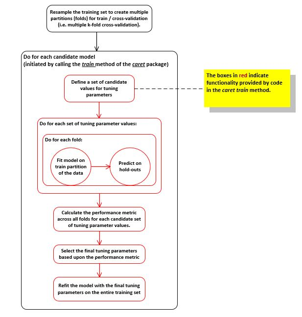

Figure 1: Flow Chart of the model parameter tuning and cross-validation processing

##### *Split the training data*

As mentioned in the process flow-chart given above, repeated k-fold cross-validation was the strategy used to split the training data into multiple training / validation datasets. This was chosen for the following reasons:

- Using just a single train/test set (partitioned from the original train set) is a single evaluation of the model and has limited ability to characterize the uncertainty in the results. This is especially true for tree-based classifiers.
- Resampling methods such as this can produce reasonable predictions of how well the model will perform on future samples.
- It is generally accepted that for medium sample sizes like this one, simple 10-fold cross-validation should provide acceptable variance, low bias (difference between the estimated and true values of performance), and is relatively quick to compute. Research indicates that repeating k-fold crossvalidation can be used to effectively increase the precision of the performance estimates while still maintaining a small bias.

For this report, there will be five repetitions each with ten folds for a total of 50 different training sets and 50 hold-out sets to estimate model performance for each candidate set of tuning parameters to try for a given model:

```r
set.seed(reportSeedToUse)
folds <- createMultiFolds(wleTrainingData$classe, k = 10, times = 5)

# Define the set of parameters to be used across all models for training and tuning
modelTrainingControl <- trainControl(method = "repeatedcv", index = folds)
```

For the folds created above, please note the following:

- Each fold contains a set of indices which are the dataset rows to train the model in question. The holdout set (used to estimate performance) is then the set of all the other rows in the dataset.
- Each fold is randomly selected according to an internal sampling algorithm, and differs slightly from all the others (in content and sometimes in size).
- Each fold and holdout set is stratified, i.e. contains roughly the same proportion of each target class as found in the overall training set from which they were created.

Given below below is code sampling the folds to illustrate the above points:

```r
# Show the length of each fold
sapply(folds, length)
```

```
## Fold01.Rep1 Fold02.Rep1 Fold03.Rep1 Fold04.Rep1 Fold05.Rep1 Fold06.Rep1
##       17661       17659       17661       17660       17661       17658
## Fold07.Rep1 Fold08.Rep1 Fold09.Rep1 Fold10.Rep1 Fold01.Rep2 Fold02.Rep2
##       17659       17659       17660       17660       17660       17661
## Fold03.Rep2 Fold04.Rep2 Fold05.Rep2 Fold06.Rep2 Fold07.Rep2 Fold08.Rep2
##       17660       17660       17661       17659       17659       17660
## Fold09.Rep2 Fold10.Rep2 Fold01.Rep3 Fold02.Rep3 Fold03.Rep3 Fold04.Rep3
##       17659       17659       17661       17658       17660       17660
## Fold05.Rep3 Fold06.Rep3 Fold07.Rep3 Fold08.Rep3 Fold09.Rep3 Fold10.Rep3
##       17660       17660       17659       17661       17659       17660
## Fold01.Rep4 Fold02.Rep4 Fold03.Rep4 Fold04.Rep4 Fold05.Rep4 Fold06.Rep4
##       17660       17660       17660       17661       17658       17660
## Fold07.Rep4 Fold08.Rep4 Fold09.Rep4 Fold10.Rep4 Fold01.Rep5 Fold02.Rep5
##       17660       17661       17658       17660       17660       17658
## Fold03.Rep5 Fold04.Rep5 Fold05.Rep5 Fold06.Rep5 Fold07.Rep5 Fold08.Rep5
##       17659       17659       17660       17660       17659       17660
## Fold09.Rep5 Fold10.Rep5
##       17661       17662
```

```r
# Show the indices in the first and last folds as an example
folds[[1]][1:15]
```

```
##  [1]  1  2  3  4  5  6  8  9 10 11 12 13 14 15 16
```

```r
folds[[25]][1:15]
```

```
##  [1]  1  2  3  4  5  6  7  9 10 12 13 14 15 16 18
```

```r
# Show the class proportions in the overall training set
table(wleTrainingData$classe) / nrow(wleTrainingData)
```

```
##
##         A         B         C         D         E
## 0.2843747 0.1935073 0.1743961 0.1638977 0.1838243
```

```r
# Class proportions for fold 3 are stratified
table(wleTrainingData[folds[[3]], ncol(wleTrainingData)]) / length(folds[[3]])
```

```
##
##         A         B         C         D         E
## 0.2843554 0.1935338 0.1743956 0.1639205 0.1837948
```

```r
# Class proportions for hold-out from fold 3 are stratified
table(wleTrainingData[-folds[[3]], ncol(wleTrainingData)]) / (nrow(wleTrainingData) - length(folds[[3]]))
```

```
##
##         A         B         C         D         E
## 0.2845487 0.1932687 0.1744008 0.1636920 0.1840898
```

##### *Train / Tune candidate models*

First the tree-based models are trained:

```r
set.seed(reportSeedToUse)
rpartFit <- train(x = wleTrainingData[, -ncol(wleTrainingData)], y = wleTrainingData$classe,
                  method = "rpart",
                  trControl = modelTrainingControl)

set.seed(reportSeedToUse)
baggedTreeFit <- train(x = wleTrainingData[, -ncol(wleTrainingData)], y = wleTrainingData$classe,
                       method = "treebag",
                       trControl = modelTrainingControl)

set.seed(reportSeedToUse)
rfFit <- train(x = wleTrainingData[, -ncol(wleTrainingData)], y = wleTrainingData$classe,
               method = "rf",
               trControl = modelTrainingControl)

set.seed(reportSeedToUse)
gbmFit <- train(x = wleTrainingData[, -ncol(wleTrainingData)], y = wleTrainingData$classe,
                method = "gbm",
                trControl = modelTrainingControl,
                verbose = FALSE)

set.seed(reportSeedToUse)
xgboostFit <- train(x = wleTrainingData[, -ncol(wleTrainingData)], y = wleTrainingData$classe,
                    method = "xgbTree",
                    trControl = modelTrainingControl,
                    verbose = FALSE)
```

Now build model-based classifiers:

```r
set.seed(reportSeedToUse)
naiveBayesFit <- train(x = wleTrainingData[, -ncol(wleTrainingData)], y = wleTrainingData$classe,
                       method = "nb",
                       trControl = modelTrainingControl)

set.seed(reportSeedToUse)
ldaFit <- train(x = wleTrainingData[, -ncol(wleTrainingData)], y = wleTrainingData$classe,
                       method = "lda",
                       trControl = modelTrainingControl)
```

## Findings

#### Model Training / Tuning Results

First, presented below are the results of the tuning and final models:

Table 1: Out-of-sample errors and final model parameters for the candidate classification models created above. The lower the OOS Error, the more accurate is its classifier.

| Model | OOS Error | Training Time (secs) | Final Tuning Parameters |
| --- | --- | --- | --- |
| rf | 0.005871 | 13630 | mtry = 2 |
| xgbTree | 0.006686 | 13398 | nrounds = 150 max_depth = 3 eta = 0.400000 gamma = 0 colsample_bytree = 0.800000 min_child_weight = 1 subsample = 0.750000 |
| treebag | 0.01369 | 975.6 | parameter = none |
| gbm | 0.04691 | 3654 | n.trees = 150 interaction.depth = 3 shrinkage = 0.100000 n.minobsinnode = 10 |
| nb | 0.2337 | 1358 | fL = 0 usekernel = TRUE adjust = 1 |
| lda | 0.3569 | 13.84 | parameter = none |
| rpart | 0.4895 | 24.53 | cp = 0.029839 |

Additionally to better visualize the estimated variance for each model, given below is a box plot of the out-of-sample error rates by model in decreasing order:

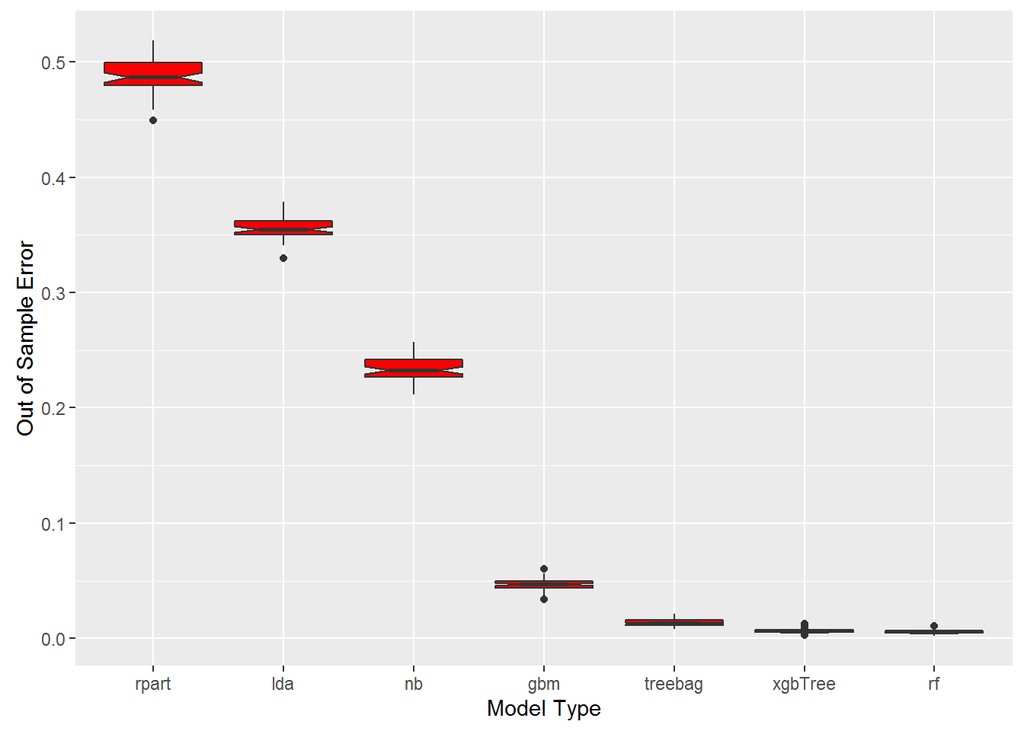

Figure 2: Distribution of the out-of-sample errors across 50 folds for the different models. The lower (closer to zero) a distribution is, the more accurate is its classifier.

#### Statistical Comparison of Models

In order to understand which models are truly the best for the WLE data, it is necessary to calculate the difference in the out-of-sample errors doing pair-wise model comparisons, and then running t-tests on those pair-wise differences to determine statistical significance.

First, the difference in out-of-sample error between each model (model 1) and EVERY other model (model 2) is calculated according to the following formula:

$OOS Error Difference = OOSError_{model1} - OOSError_{model2}$;

The boxplots of these differences are then shown below for each model:

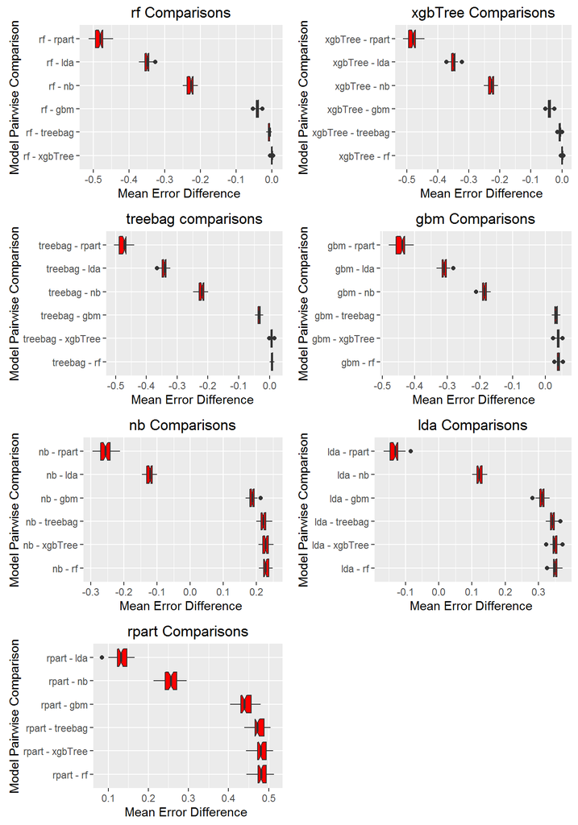

Figure 3: Distribution of the difference between out-of-sample errors across 50 folds for the different model pairwise comparisons

Next, perform a t-test on each model comparison’s mean difference in out-of-sample error according to the following hypotheses:

$H_{0}: \mu_{OOSError, model1} - \mu_{OOSError, model2} = 0$; $H_{a}: \mu_{OOSError, model1} - \mu_{OOSError, model2} < 0$

For the above, the significance level $\alpha$ will need to be adjusted lower to $\alpha / m$ (i.e. the *Bonferroni correction*) in order to reject $H_{0}$ as the chance of a rare event increases with multiple comparisons, and therefore, the likelihood of incorrectly rejecting $H_{0}$ increases.  
Here $m = n! / (n - k)!$, where **m** = total number of comparisons, **n** = number of models, and **k** = number of models in a single comparison. Plugging in the numbers then produces the following:  
$m = 7! / (7 - 2)! = 42$  
using the standard $\alpha = 0.05$, the significance level $= 0.05 / 42 = 0.0012$

$H_{0}$ will therefore be rejected if for a given model-to-model comparison t-test, the corresponding *p-value* is less than 0.0012. In that case, the data provides evidence that Model 1’s error rate is actually lower than Model 2’s (i.e. $H_{a}$ is true).

Table 2: Model pair-wise t-test comparisons

| Model 1 | Model 2 | Mean Error Difference | p-value | t-statistic | Reject $H_{0}$ |
| --- | --- | --- | --- | --- | --- |
| rf | xgbTree | -0.0008153 | 0.002882 | -2.888 | FALSE |
| rf | treebag | -0.007818 | 1.345e-22 | -17.1 | TRUE |
| rf | gbm | -0.04104 | 2.66e-47 | -58.5 | TRUE |
| rf | nb | -0.2279 | 1.977e-67 | -151.5 | TRUE |
| rf | lda | -0.3511 | 1.056e-77 | -245.7 | TRUE |
| rf | rpart | -0.4837 | 5.55e-75 | -216.2 | TRUE |
| xgbTree | rf | 0.0008153 | 0.9971 | 2.888 | FALSE |
| xgbTree | treebag | -0.007002 | 8.397e-20 | -14.62 | TRUE |
| xgbTree | gbm | -0.04022 | 2.747e-46 | -55.74 | TRUE |
| xgbTree | nb | -0.227 | 5.049e-66 | -141.8 | TRUE |
| xgbTree | lda | -0.3503 | 3.309e-77 | -240 | TRUE |
| xgbTree | rpart | -0.4828 | 5.202e-75 | -216.5 | TRUE |
| treebag | rf | 0.007818 | 1 | 17.1 | FALSE |
| treebag | xgbTree | 0.007002 | 1 | 14.62 | FALSE |
| treebag | gbm | -0.03322 | 2.162e-40 | -42.01 | TRUE |
| treebag | nb | -0.22 | 7.573e-67 | -147.4 | TRUE |
| treebag | lda | -0.3432 | 3.028e-77 | -240.5 | TRUE |
| treebag | rpart | -0.4758 | 7.269e-75 | -215 | TRUE |
| gbm | rf | 0.04104 | 1 | 58.5 | FALSE |
| gbm | xgbTree | 0.04022 | 1 | 55.74 | FALSE |
| gbm | treebag | 0.03322 | 1 | 42.01 | FALSE |
| gbm | nb | -0.1868 | 2e-64 | -131.5 | TRUE |
| gbm | lda | -0.31 | 3.949e-75 | -217.7 | TRUE |
| gbm | rpart | -0.4426 | 9.777e-72 | -185.6 | TRUE |
| nb | rf | 0.2279 | 1 | 151.5 | FALSE |
| nb | xgbTree | 0.227 | 1 | 141.8 | FALSE |
| nb | treebag | 0.22 | 1 | 147.4 | FALSE |
| nb | gbm | 0.1868 | 1 | 131.5 | FALSE |
| nb | lda | -0.1232 | 5.425e-52 | -73.11 | TRUE |
| nb | rpart | -0.2558 | 1.564e-58 | -99.61 | TRUE |
| lda | rf | 0.3511 | 1 | 245.7 | FALSE |
| lda | xgbTree | 0.3503 | 1 | 240 | FALSE |
| lda | treebag | 0.3432 | 1 | 240.5 | FALSE |
| lda | gbm | 0.31 | 1 | 217.7 | FALSE |
| lda | nb | 0.1232 | 1 | 73.11 | FALSE |
| lda | rpart | -0.1326 | 2.708e-45 | -53.15 | TRUE |
| rpart | rf | 0.4837 | 1 | 216.2 | FALSE |
| rpart | xgbTree | 0.4828 | 1 | 216.5 | FALSE |
| rpart | treebag | 0.4758 | 1 | 215 | FALSE |
| rpart | gbm | 0.4426 | 1 | 185.6 | FALSE |
| rpart | nb | 0.2558 | 1 | 99.61 | FALSE |
| rpart | lda | 0.1326 | 1 | 53.15 | FALSE |

## Predictions on the Test Set

Now run predictions on the test dataset using the Random Forest (rf) model trained above, and save the results to a file:

```r
# Run predictions using the rf model
testPredictions <- predict(rfFit, newdata = wleTestData[, -ncol(wleTestData)])

# Combine the problem IDs (last column) with the results and write to an output file
predictionOutput <- data.frame(problem_id = wleTestData[, ncol(wleTestData)],
                               classe = factor(testPredictions))
write.csv(predictionOutput, file = "wle-testpredictions.csv", row.names = FALSE)
```